# California Housing Prices

Diego Alejandro Mernies

Primer cuatrimestre 2019

#Introducción Realizaremos una análisis de los datos de las casas que se encuentran en un distrito determinado de **California** y algunas estadísticas basadas en el censo de 1990.

##Objetivo Predecir el precio de las casa de la época con un modelo de regresión lineal.

En primer lugar cargamos las librerías requeridas. Si no las tiene en su sistema, puede instalarlas con `install.packages("librería")`.

```r
library(readr)
library(dplyr)
library(corrplot)
library(ggplot2)
library(scales)
library(rms)
```

##Definición de contantes A continuación se define las **constantes** que se utilizarán en el proyecto.

```r
# URL donde reside el dataset a utilizar
dataurl <- "https://raw.githubusercontent.com/dmerniestic1987/tp_ciencia_datos_california_housing/master/input/housing.csv"
# Ubicación local en donde se guardará el dataset para su procesamiento
datadir <- "~/workspace/R/data"
```

# Carga de datos

## Set de datos

El set de datos es un archivo .csv (comma separated value) de exactamente 10 columnas y 20641 filas de las cuales la primera contiene los nombres. El archivo de input original se llama **housing.csv** y se tomó de [California Housing Price] (https://www.kaggle.com/camnugent/california-housing-prices), pero fue subido a un repositorio GIT para simplificar la descarga de los datos y controlar las versiones. El repositorio GIT se puede explorar ingresando a: https://github.com/dmerniestic1987/tp_ciencia_datos_california_housing.

Los datos pertenecen a las casas que se encuentran en un distrito de California y algunas estadísticas basadas en los datos del censo de 1990. Las variables son:

| Variable | Descripción |
| --- | --- |
| longitude | Qué tan lejos al oeste este está una casa. Un valor más alto está más al oeste. |
| latitude | Qué tan lejos al norte está una casa. Un valor más alto está más al norte. |
| housing_median_age | Edad media de una casa dentro de un bloque de casas. Un número más bajo es un edificio más nuevo. |
| total_rooms | Número total de ambientes dentro de un bloque de casas. |
| total_bedrooms | Número total de habitaciones dentro de un bloque de casas. |
| population | Número total de personas que residen dentro de un bloque de casas. |
| households | Número total de hogares, un grupo de personas que residen dentro de una unidad de hogar, por un bloque. |
| median_income | Ingreso promedio para hogares dentro de un bloque de casas (medido en decenas de miles de dólares estadounidenses) |
| median_house_value | Valor medio de la vivienda para hogares dentro de un bloque (medido en dólares estadounidenses) |
| ocean_proximity | Ubicación de la casa con relación al oceano o mar. |

##Descarga del set de datos Descargamos los datos.

```r
datafile <- paste(datadir, "housing.csv", sep = "/")
```

En primer lugar se verifica si es necesario crear un directorio para almacenar el archivo.

```r
if (dir.exists(datadir)) {
  print(paste("El directorio ", datadir, " ya existe."))
} else {
  print(paste("Creando directorio de datos", datadir, "."))
  dir.create(datadir)
}
```

```
## [1] "El directorio  ~/workspace/R/data  ya existe."
```

El segundo lugar se descarga la última versión del archivo para poder utilizar la información actualizada.

```r
if (file.exists(datafile)) {
  print(paste("El archivo ", datafile, " ya existe, lo elimino."))
  file.remove(datafile)
}
```

```
## [1] "El archivo  ~/workspace/R/data/housing.csv  ya existe, lo elimino."
```

```
## [1] TRUE
```

```r
download.file(dataurl, datafile, method="auto")
```

##Lectura de los datos

```r
  dfhousing <- read.csv(datafile)
```

##Control de datos Verifcamos que nos nombres de las columnas sean correctos

```r
colnames(dfhousing)
```

```
##  [1] "longitude"          "latitude"           "housing_median_age"
##  [4] "total_rooms"        "total_bedrooms"     "population"
##  [7] "households"         "median_income"      "median_house_value"
## [10] "ocean_proximity"
```

Verificamos los tipos de datos de las columnas

```r
dim(dfhousing)
```

```
## [1] 20640    10
```

```r
str(dfhousing)
```

```
## 'data.frame':    20640 obs. of  10 variables:
##  $ longitude         : num  -122 -122 -122 -122 -122 ...
##  $ latitude          : num  37.9 37.9 37.9 37.9 37.9 ...
##  $ housing_median_age: num  41 21 52 52 52 52 52 52 42 52 ...
##  $ total_rooms       : num  880 7099 1467 1274 1627 ...
##  $ total_bedrooms    : num  129 1106 190 235 280 ...
##  $ population        : num  322 2401 496 558 565 ...
##  $ households        : num  126 1138 177 219 259 ...
##  $ median_income     : num  8.33 8.3 7.26 5.64 3.85 ...
##  $ median_house_value: num  452600 358500 352100 341300 342200 ...
##  $ ocean_proximity   : Factor w/ 5 levels "<1H OCEAN","INLAND",..: 4 4 4 4 4 4 4 4 4 4 ...
```

Verificamos los primeros registros del archivo para verificar los formatos

```r
head(dfhousing, give.attr=FALSE)
```

|  | longitude | latitude | housing_median_age | total_rooms | total_bedrooms | population | households | median_income | median_house_value | ocean_proximity |
| --- | --- | --- | --- | --- | --- | --- | --- | --- | --- | --- |
| 1 | -122.23 | 37.88 | 41 | 880 | 129 | 322 | 126 | 8.3252 | 452600 | NEAR BAY |
| 2 | -122.22 | 37.86 | 21 | 7099 | 1106 | 2401 | 1138 | 8.3014 | 358500 | NEAR BAY |
| 3 | -122.24 | 37.85 | 52 | 1467 | 190 | 496 | 177 | 7.2574 | 352100 | NEAR BAY |
| 4 | -122.25 | 37.85 | 52 | 1274 | 235 | 558 | 219 | 5.6431 | 341300 | NEAR BAY |
| 5 | -122.25 | 37.85 | 52 | 1627 | 280 | 565 | 259 | 3.8462 | 342200 | NEAR BAY |
| 6 | -122.25 | 37.85 | 52 | 919 | 213 | 413 | 193 | 4.0368 | 269700 | NEAR BAY |

Verificamos los últimos registros del archivo para verificar los formatos

```r
tail(dfhousing, give.attr=FALSE)
```

|  | longitude | latitude | housing_median_age | total_rooms | total_bedrooms | population | households | median_income | median_house_value | ocean_proximity |
| --- | --- | --- | --- | --- | --- | --- | --- | --- | --- | --- |
| 20635 | -121.56 | 39.27 | 28 | 2332 | 395 | 1041 | 344 | 3.7125 | 116800 | INLAND |
| 20636 | -121.09 | 39.48 | 25 | 1665 | 374 | 845 | 330 | 1.5603 | 78100 | INLAND |
| 20637 | -121.21 | 39.49 | 18 | 697 | 150 | 356 | 114 | 2.5568 | 77100 | INLAND |
| 20638 | -121.22 | 39.43 | 17 | 2254 | 485 | 1007 | 433 | 1.7000 | 92300 | INLAND |
| 20639 | -121.32 | 39.43 | 18 | 1860 | 409 | 741 | 349 | 1.8672 | 84700 | INLAND |
| 20640 | -121.24 | 39.37 | 16 | 2785 | 616 | 1387 | 530 | 2.3886 | 89400 | INLAND |

Obtenemos un resumen de las variables para verificar los datos.

```r
summary(dfhousing)
```

```
##    longitude         latitude     housing_median_age  total_rooms
##  Min.   :-124.3   Min.   :32.54   Min.   : 1.00      Min.   :    2
##  1st Qu.:-121.8   1st Qu.:33.93   1st Qu.:18.00      1st Qu.: 1448
##  Median :-118.5   Median :34.26   Median :29.00      Median : 2127
##  Mean   :-119.6   Mean   :35.63   Mean   :28.64      Mean   : 2636
##  3rd Qu.:-118.0   3rd Qu.:37.71   3rd Qu.:37.00      3rd Qu.: 3148
##  Max.   :-114.3   Max.   :41.95   Max.   :52.00      Max.   :39320
##
##  total_bedrooms     population      households     median_income
##  Min.   :   1.0   Min.   :    3   Min.   :   1.0   Min.   : 0.4999
##  1st Qu.: 296.0   1st Qu.:  787   1st Qu.: 280.0   1st Qu.: 2.5634
##  Median : 435.0   Median : 1166   Median : 409.0   Median : 3.5348
##  Mean   : 537.9   Mean   : 1425   Mean   : 499.5   Mean   : 3.8707
##  3rd Qu.: 647.0   3rd Qu.: 1725   3rd Qu.: 605.0   3rd Qu.: 4.7432
##  Max.   :6445.0   Max.   :35682   Max.   :6082.0   Max.   :15.0001
##  NA's   :207
##  median_house_value   ocean_proximity
##  Min.   : 14999     <1H OCEAN :9136
##  1st Qu.:119600     INLAND    :6551
##  Median :179700     ISLAND    :   5
##  Mean   :206856     NEAR BAY  :2290
##  3rd Qu.:264725     NEAR OCEAN:2658
##  Max.   :500001
##
```

El resumen estadísticos se detectó: * Es necesario limpiar los NA’S de la columna total_bedrooms. * Existen sólo 5 casas que están en una Isla. * Los valores máximos de total_rooms, total_bedrooms, population y households son muy altos en comparación a la media.

Se realiza una exploración de los datos para analizar su distribución.

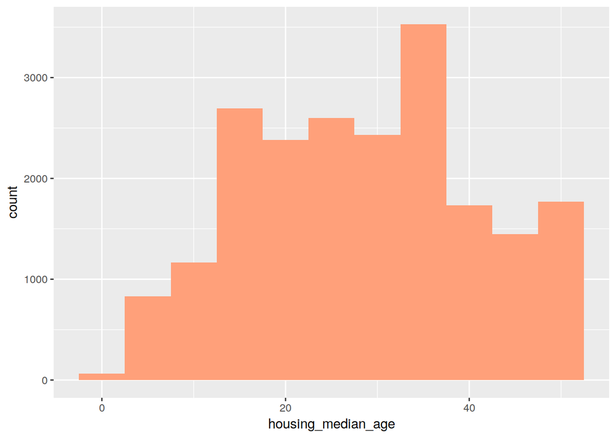

```r
ggplot(dfhousing) +
  geom_histogram(aes(x=housing_median_age), binwidth=5, fill="lightsalmon", bins=30)
```

Mostramos la cantidad de hogares como un diagrama de densidad.

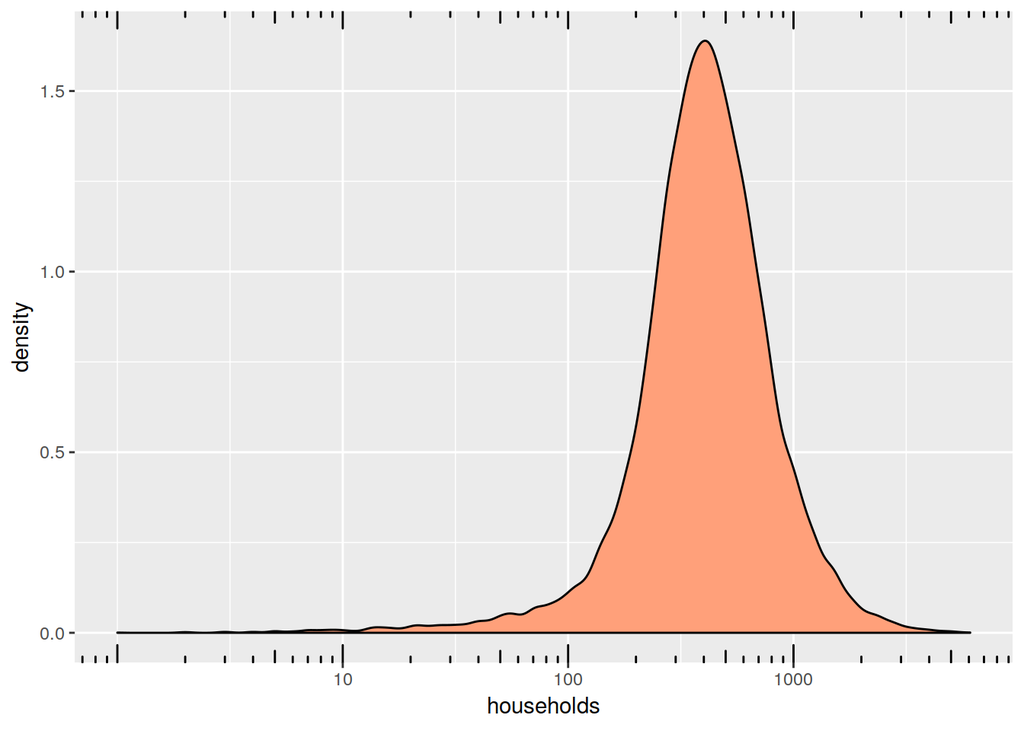

```r
ggplot(dfhousing) +
  geom_density(aes(x=households), fill="lightsalmon") +
  scale_x_log10(breaks=c(10, 100, 1000, 100000)) +
  annotation_logticks(sides="bt")
```

A contiuación se observan los ingresos medios.

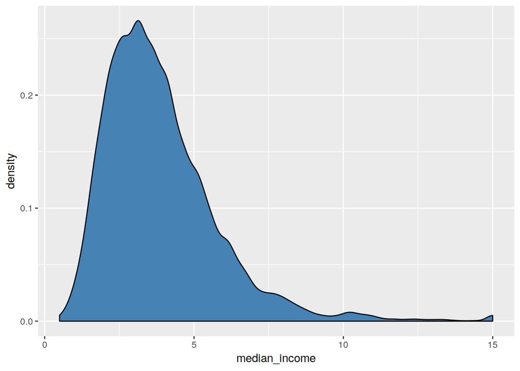

```r
ggplot(dfhousing) +
  geom_density(aes(x=median_income), fill="steel blue")
```

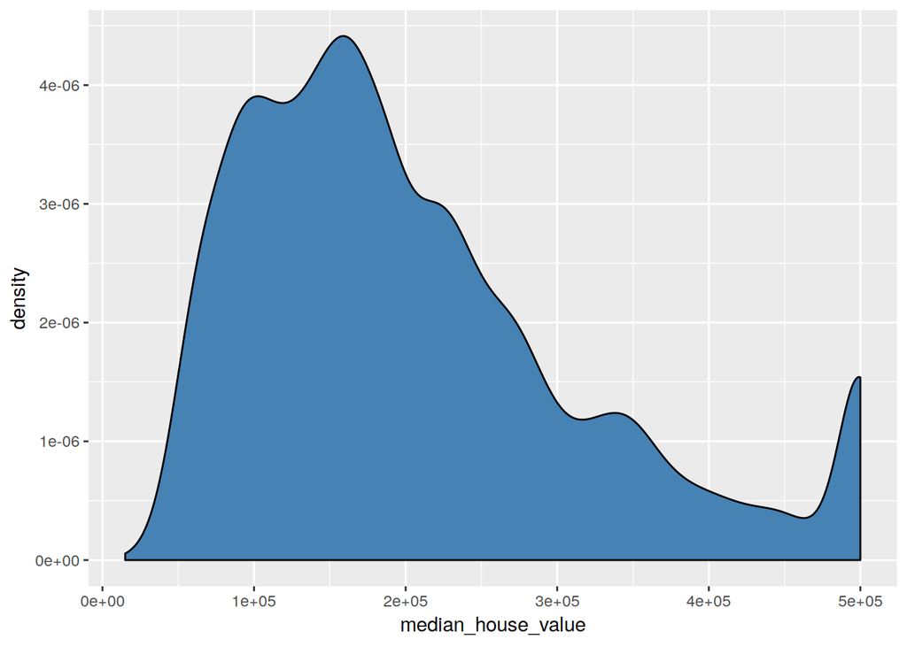

```r
ggplot(dfhousing) +
  geom_density(aes(x=median_house_value), fill="steel blue")
```

Analizamos la cantidad de casas según la proximidad al mar.

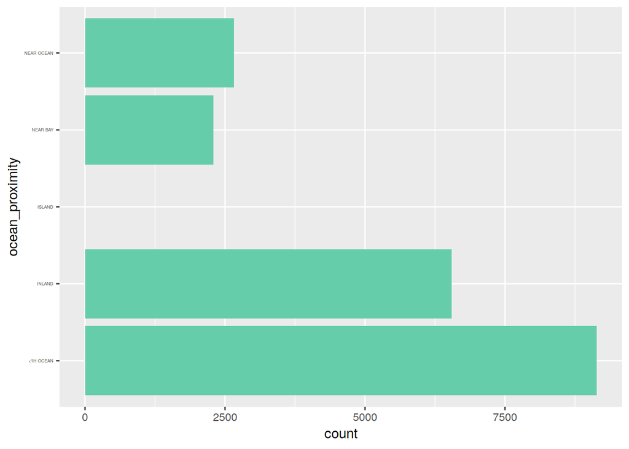

```r
ggplot(dfhousing) +
  geom_bar(aes(x=ocean_proximity), fill="mediumaquamarine")+
  coord_flip() +
  theme(axis.text.y=element_text(size=rel(0.4)))
```

##Limpieza de datos Se eliminan los NA de **total_bedrooms**

```r
dfhousing$total_bedrooms[is.na(dfhousing$total_bedrooms)]= median(dfhousing$total_bedrooms, na.rm=TRUE)
```

Para corregir los altos valores máximos se crean dos nuevas columnas: *mean_bedrooms: El cuociente entre habitaciones por hogares.* mean_rooms: El cuociente entre ambientes por hogares. Posteriormente eliminamos las columnas total_bedrooms y total_rooms

```r
dfhousing$mean_bedrooms = dfhousing$total_bedrooms / dfhousing$households
dfhousing$mean_rooms = dfhousing$total_rooms / dfhousing$households
```

```r
#Eliminamos las columnas total_bedrooms y total_rooms para usar el nuevo índice
drops = c('total_bedrooms', 'total_rooms')
dfhousing = dfhousing[ , !(names(dfhousing) %in% drops) ]
```

Controlamos la nueva estructura de la tabla

```r
head(dfhousing)
```

|  | longitude | latitude | housing_median_age | population | households | median_income | median_house_value | ocean_proximity | mean_bedrooms | mean_rooms |
| --- | --- | --- | --- | --- | --- | --- | --- | --- | --- | --- |
| 1 | -122.23 | 37.88 | 41 | 322 | 126 | 8.3252 | 452600 | NEAR BAY | 1.0238095 | 6.984127 |
| 2 | -122.22 | 37.86 | 21 | 2401 | 1138 | 8.3014 | 358500 | NEAR BAY | 0.9718805 | 6.238137 |
| 3 | -122.24 | 37.85 | 52 | 496 | 177 | 7.2574 | 352100 | NEAR BAY | 1.0734463 | 8.288136 |
| 4 | -122.25 | 37.85 | 52 | 558 | 219 | 5.6431 | 341300 | NEAR BAY | 1.0730594 | 5.817352 |
| 5 | -122.25 | 37.85 | 52 | 565 | 259 | 3.8462 | 342200 | NEAR BAY | 1.0810811 | 6.281853 |
| 6 | -122.25 | 37.85 | 52 | 413 | 193 | 4.0368 | 269700 | NEAR BAY | 1.1036269 | 4.761658 |

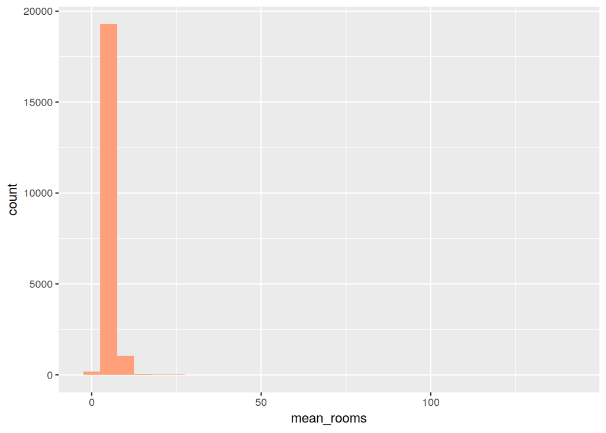

```r
ggplot(dfhousing) +
  geom_histogram(aes(x=mean_rooms), binwidth=5, fill="lightsalmon", bins=30)
```

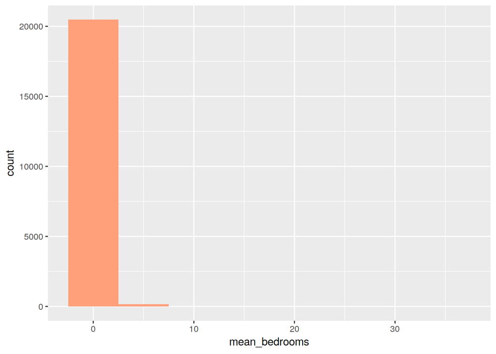

```r
ggplot(dfhousing) +
  geom_histogram(aes(x=mean_bedrooms), binwidth=5, fill="lightsalmon", bins=30)
```

```r
#Creamos un nuevo dataframe auxiliar sin ocean_proximity que es categórico, ni median_house_value
#que el dato que se intentará predecir. Luego se escalan los valores para trabajarlos con gráficos más legibles.
drops = c('ocean_proximity','median_house_value')
dfhousing_aux =  dfhousing[ , !(names(dfhousing) %in% drops)]
dfscaledhousing_aux = scale(dfhousing_aux)
```

```r
#Creamos un nuevo dataframe que contenga solo la proximidad al mar. Luego limpiamos el resto de las columnas
dropsCategories = c('ocean_proximity', 'median_house_value')
dfcat_aux =  dfhousing[ , (names(dfhousing) %in% dropsCategories)]
```

```r
#Combinamos las dataframes y generamos un nuevo que contenga la combinación con los datos escalados y las categorías.
dfhousing_clean = cbind(DataSet1=dfcat_aux, DataSet2=dfscaledhousing_aux, median_house_value=dfhousing$median_house_value)

dropClean = c('DataSet1.median_house_value')
dfhousing_clean =  dfhousing_clean[ , !(names(dfhousing_clean) %in% dropClean)]

newNames = c('ocean_proximity', 'longitude', 'latitude', 'housing_median_age', 'population', 'households', 'median_income', 'mean_bedrooms', 'mean_rooms', 'median_house_value')
colnames(dfhousing_clean) <- newNames
```

## Visualización de correlaciones

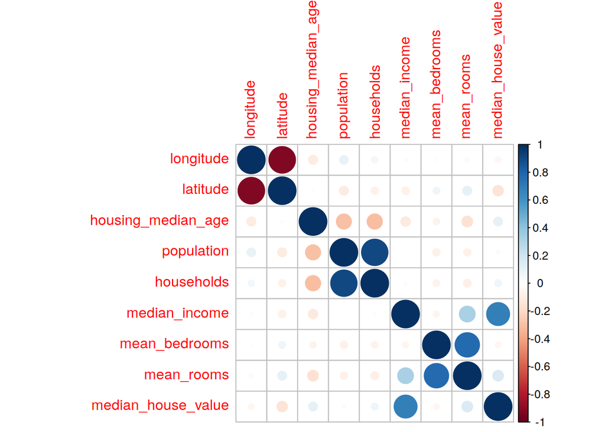

```r
dfhousing_clean %>%
    select_if(is.numeric) %>%
    cor() %>%
    corrplot()
```

En base al gráfico de correlación se puede determinó que existe una fuerte relación entre la cantidad de la población y la cantidad de hogares. También que el precio de las casas está relacionado con el ingreso medio por lo que pueden haber barrios más caros.

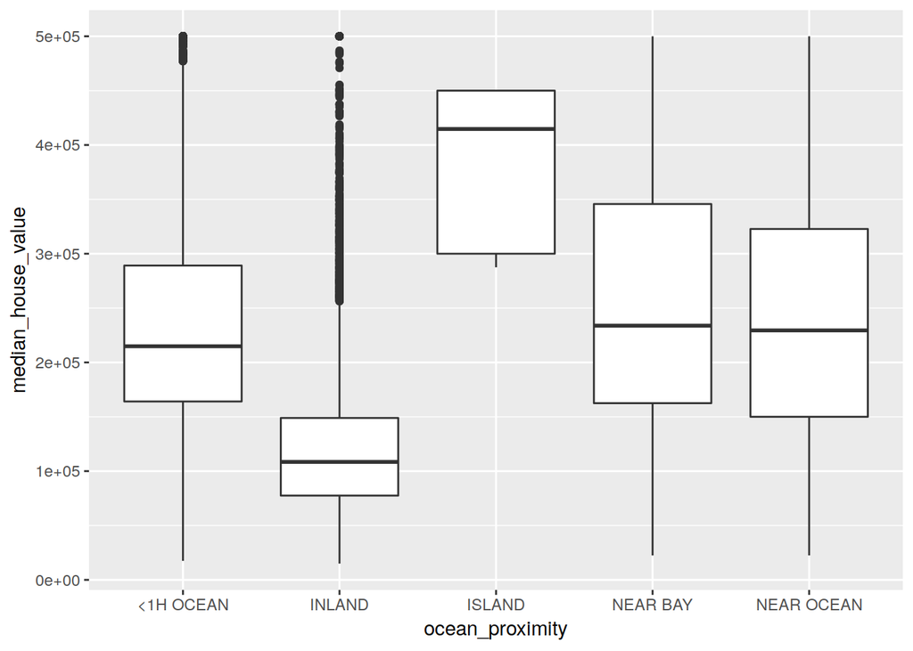

```r
ggplot(dfhousing_clean) +
    geom_boxplot(aes(x=ocean_proximity, y=median_house_value))
```

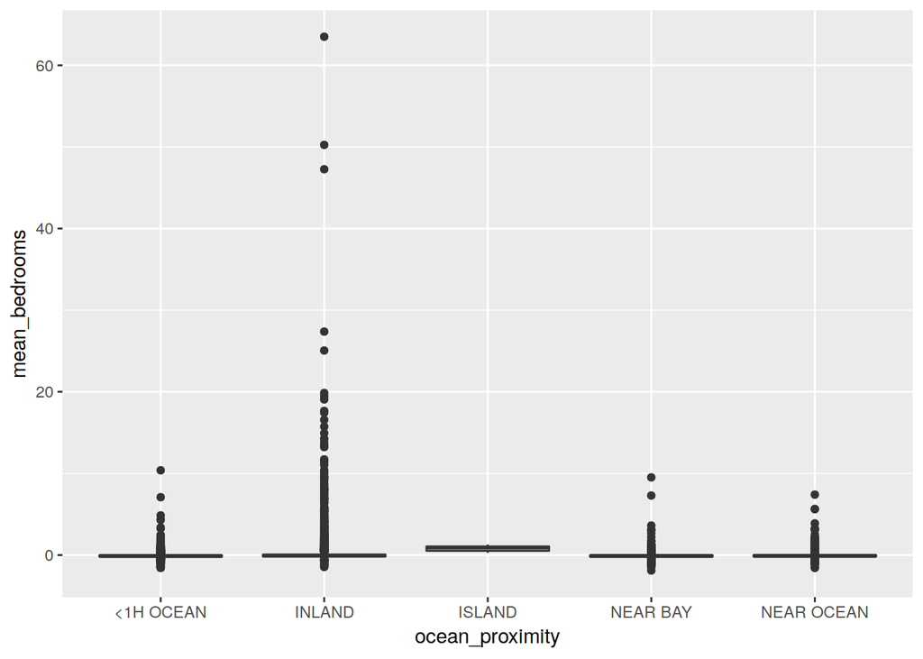

```r
ggplot(dfhousing_clean) +
    geom_boxplot(aes(x=ocean_proximity, y=mean_bedrooms))
```

#Creación de modelos ##Creación de datos de entrenamiento y pruebas Crearemos dos datasets: Uno de entrenamiento y otro de pruebas utilizando la proporción 80 para entrenamiento y 20 para test.

```r
set.seed(77222)
seleccion <- runif(dim(dfhousing_clean)[1])

dftrain <- select(dfhousing_clean, population, median_house_value, median_income, mean_rooms, households, ocean_proximity, housing_median_age, mean_bedrooms)[seleccion < 0.8, ]
dftest <- select(dfhousing_clean, population, median_house_value, median_income, mean_rooms, households, ocean_proximity, housing_median_age, mean_bedrooms)[seleccion >= 0.8, ]
```

##Modelo 1. El primer modelo utiliza los predictores: **median_income**, **mean_rooms** y **population** para intentar predecir el valor de las propiedades plasmados en **median_house_value**.

```r
lineModel <- lm( median_house_value~median_income+mean_rooms+population, data=dftrain)
summary(lineModel)
```

```
##
## Call:
## lm(formula = median_house_value ~ median_income + mean_rooms +
##     population, data = dftrain)
##
## Residuals:
##     Min      1Q  Median      3Q     Max
## -480471  -54589  -16935   36069  601766
##
## Coefficients:
##               Estimate Std. Error t value Pr(>|t|)
## (Intercept)   206811.7      644.1  321.09  < 2e-16 ***
## median_income  85664.2      710.7  120.54  < 2e-16 ***
## mean_rooms    -16903.1      866.9  -19.50  < 2e-16 ***
## population     -4374.6      644.2   -6.79 1.16e-11 ***
## ---
## Signif. codes:  0 '***' 0.001 '**' 0.01 '*' 0.05 '.' 0.1 ' ' 1
##
## Residual standard error: 82870 on 16553 degrees of freedom
## Multiple R-squared:  0.4846, Adjusted R-squared:  0.4845
## F-statistic:  5187 on 3 and 16553 DF,  p-value: < 2.2e-16
```

```r
print("VIF()")
```

```
## [1] "VIF()"
```

```r
vif(lineModel)
```

```
## median_income    mean_rooms    population
##      1.193921      1.200740      1.007058
```

```r
predModel <- predict(lineModel, newdata = dftrain)
summary(predModel)
```

```
##    Min. 1st Qu.  Median    Mean 3rd Qu.    Max.
## -279062  152304  193054  206861  244038  712162
```

```r
print("* * * * * * * mean(predModel) * * * * * *")
```

```
## [1] "* * * * * * * mean(predModel) * * * * * *"
```

```r
mean(predModel)
```

```
## [1] 206861.1
```

```r
print("* * * * * * * sd(predModel) * * * * * *")
```

```
## [1] "* * * * * * * sd(predModel) * * * * * *"
```

```r
sd(predModel)
```

```
## [1] 80341.82
```

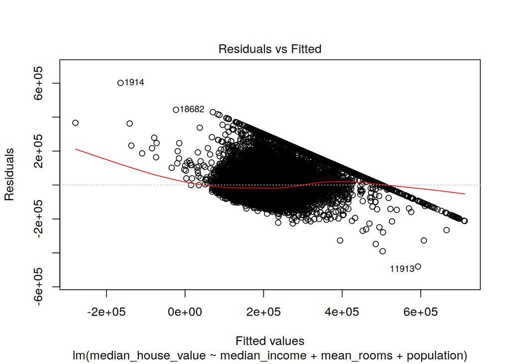

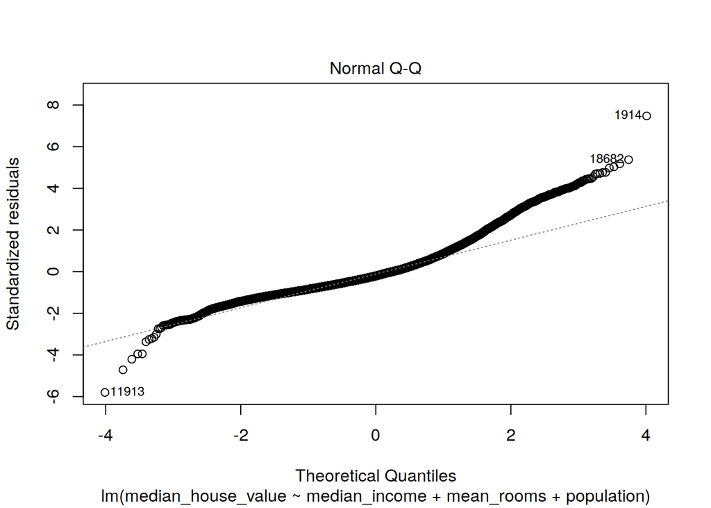

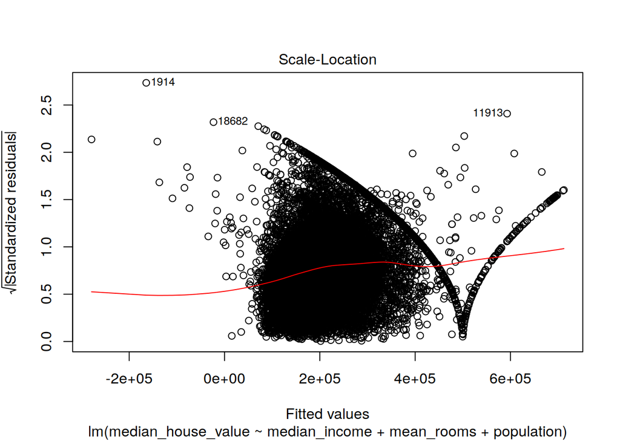

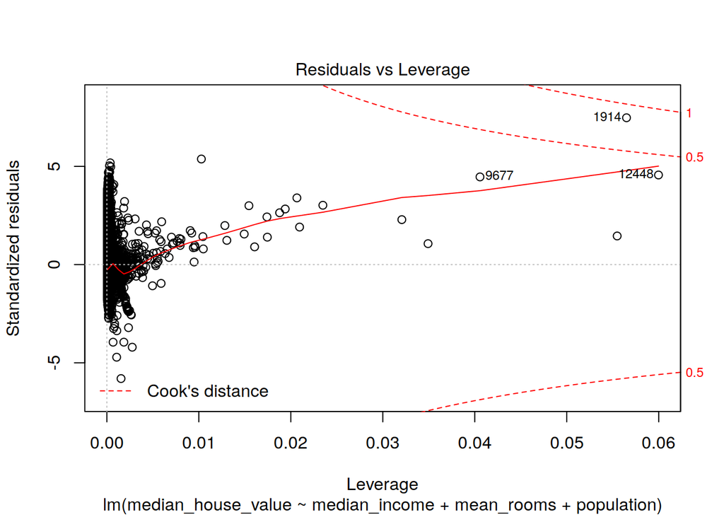

```r
plot(lineModel)
```

##Modelo 2. El segundo modelo utiliza los predictores: **median_income**, **mean_rooms**, **population** y **housing_median_age** para intentar predecir el valor de las propiedades plasmados en **median_house_value**.

```r
lineModel2 <- lm( median_house_value~median_income+mean_rooms+population+housing_median_age, data=dftrain)
summary(lineModel2)
```

```
##
## Call:
## lm(formula = median_house_value ~ median_income + mean_rooms +
##     population + housing_median_age, data = dftrain)
##
## Residuals:
##     Min      1Q  Median      3Q     Max
## -480596  -53078  -15345   35572  506018
##
## Coefficients:
##                    Estimate Std. Error t value Pr(>|t|)
## (Intercept)        206874.5      624.5 331.267  < 2e-16 ***
## median_income       86635.9      689.7 125.610  < 2e-16 ***
## mean_rooms         -11633.6      856.1 -13.590  < 2e-16 ***
## population           2300.4      657.5   3.499 0.000469 ***
## housing_median_age  21885.3      673.5  32.497  < 2e-16 ***
## ---
## Signif. codes:  0 '***' 0.001 '**' 0.01 '*' 0.05 '.' 0.1 ' ' 1
##
## Residual standard error: 80350 on 16552 degrees of freedom
## Multiple R-squared:  0.5155, Adjusted R-squared:  0.5154
## F-statistic:  4402 on 4 and 16552 DF,  p-value: < 2.2e-16
```

```r
print("* * * * * * * vif(lineModel2) * * * * * * *")
```

```
## [1] "* * * * * * * vif(lineModel2) * * * * * * *"
```

```r
vif(lineModel2)
```

```
##      median_income         mean_rooms         population
##           1.196169           1.245426           1.115959
## housing_median_age
##           1.153457
```

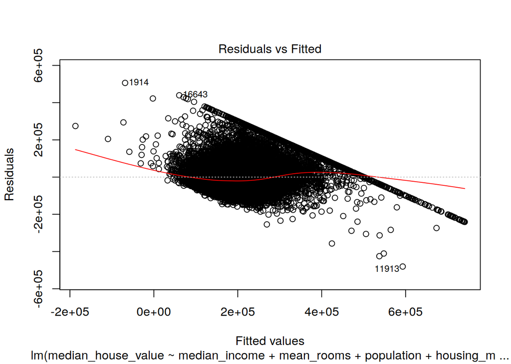

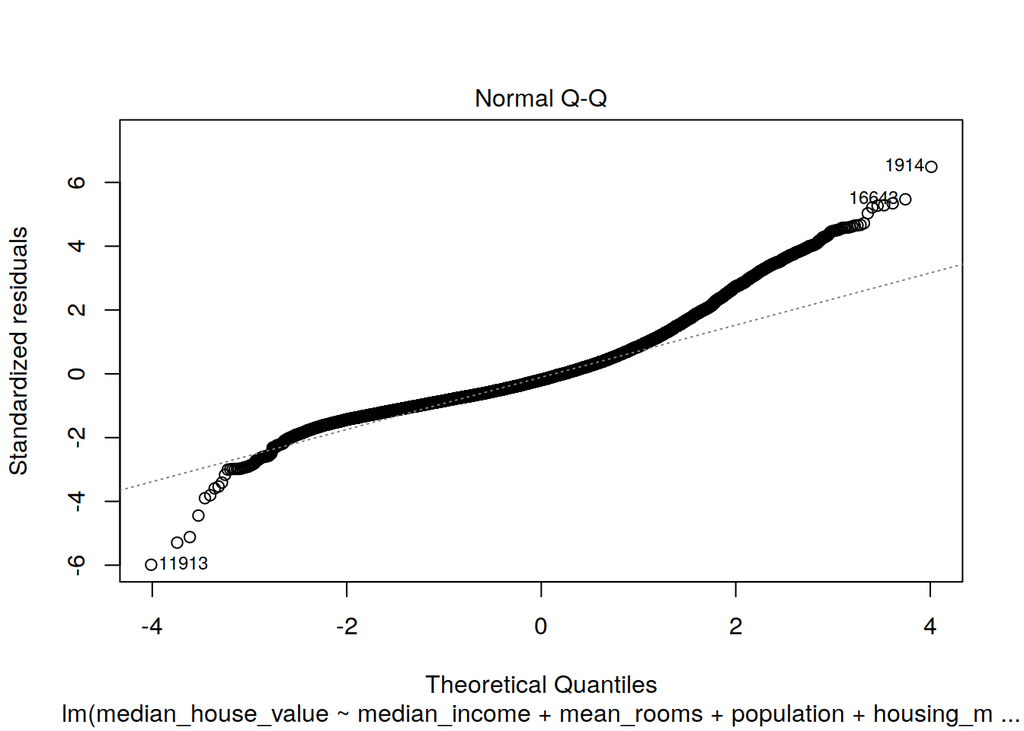

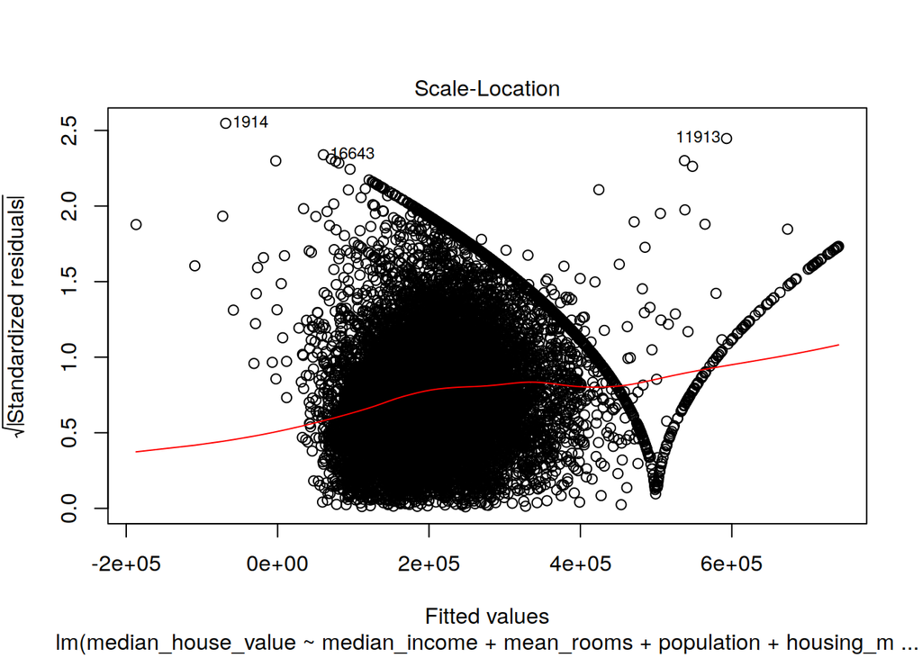

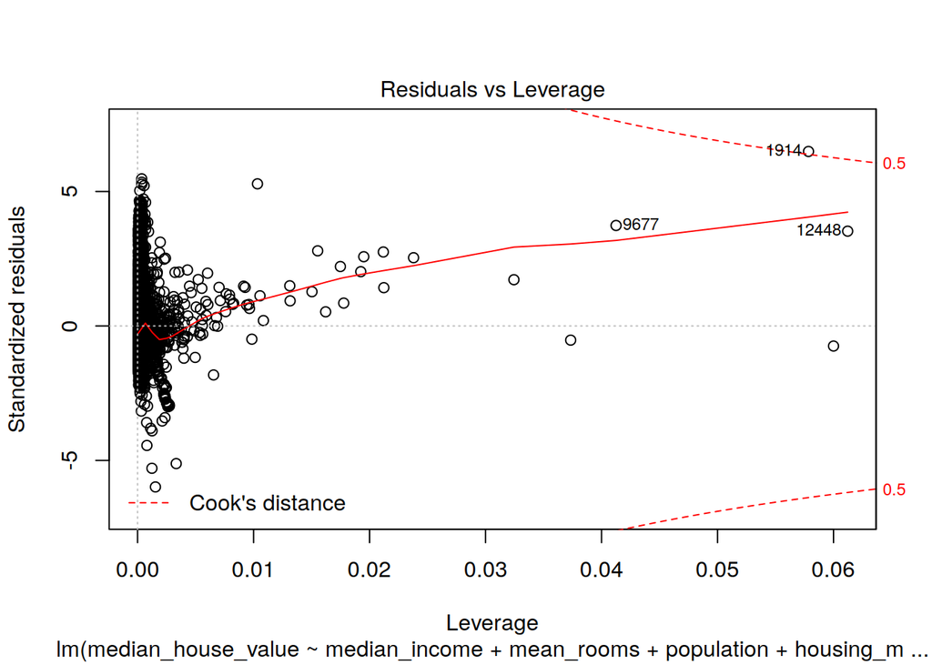

```r
plot(lineModel2)
```

```r
predModel2 <- predict(lineModel2, newdata = dftrain)
summary(predModel2)
```

```
##    Min. 1st Qu.  Median    Mean 3rd Qu.    Max.
## -186920  151428  194179  206861  246100  741045
```

```r
print("* * * * * * * mean(predModel3) * * * * * *")
```

```
## [1] "* * * * * * * mean(predModel3) * * * * * *"
```

```r
mean(predModel2)
```

```
## [1] 206861.1
```

```r
print("* * * * * * * sd(predModel3) * * * * * *")
```

```
## [1] "* * * * * * * sd(predModel3) * * * * * *"
```

```r
sd(predModel2)
```

```
## [1] 82864.89
```

##Modelo 3. El último modelo utiliza los predictores: **mean_bedrooms**, **mean_rooms**, **median_income** y **housing_median_age** para intentar predecir el valor de las propiedades plasmados en **median_house_value**.

```r
lineModel3 <- lm( median_house_value~mean_bedrooms+mean_rooms+housing_median_age+median_income, data=dftrain)
summary(lineModel3)
```

```
##
## Call:
## lm(formula = median_house_value ~ mean_bedrooms + mean_rooms +
##     housing_median_age + median_income, data = dftrain)
##
## Residuals:
##      Min       1Q   Median       3Q      Max
## -1119915   -51878   -14448    34520   504638
##
## Coefficients:
##                    Estimate Std. Error t value Pr(>|t|)
## (Intercept)        206844.9      620.8  333.19   <2e-16 ***
## mean_bedrooms       16325.1     1128.1   14.47   <2e-16 ***
## mean_rooms         -25412.7     1250.6  -20.32   <2e-16 ***
## housing_median_age  20679.6      636.8   32.47   <2e-16 ***
## median_income       91812.7      771.6  118.99   <2e-16 ***
## ---
## Signif. codes:  0 '***' 0.001 '**' 0.01 '*' 0.05 '.' 0.1 ' ' 1
##
## Residual standard error: 79870 on 16552 degrees of freedom
## Multiple R-squared:  0.5212, Adjusted R-squared:  0.5211
## F-statistic:  4504 on 4 and 16552 DF,  p-value: < 2.2e-16
```

```r
print("* * * * * * * vif(lineModel3) * * * * * * *")
```

```
## [1] "* * * * * * * vif(lineModel3) * * * * * * *"
```

```r
vif(lineModel3)
```

```
##      mean_bedrooms         mean_rooms housing_median_age
##           2.222833           2.689508           1.043609
##      median_income
##           1.514901
```

Predicción del modelo

```r
predModel3 <- predict(lineModel3, newdata = dftrain)
summary(predModel3)
```

```
##    Min. 1st Qu.  Median    Mean 3rd Qu.    Max.
##  -97548  151886  194146  206861  245737 1319915
```

```r
print("* * * * * * * mean(predModel3) * * * * * *")
```

```
## [1] "* * * * * * * mean(predModel3) * * * * * *"
```

```r
mean(predModel3)
```

```
## [1] 206861.1
```

```r
print("* * * * * * * sd(predModel3) * * * * * *")
```

```
## [1] "* * * * * * * sd(predModel3) * * * * * *"
```

```r
sd(predModel3)
```

```
## [1] 83321.74
```

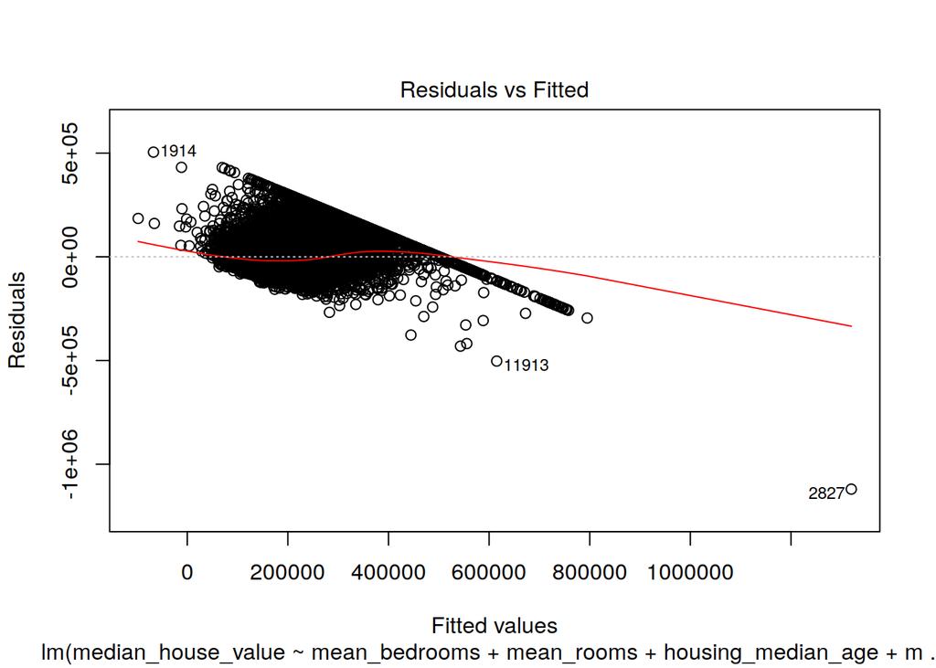

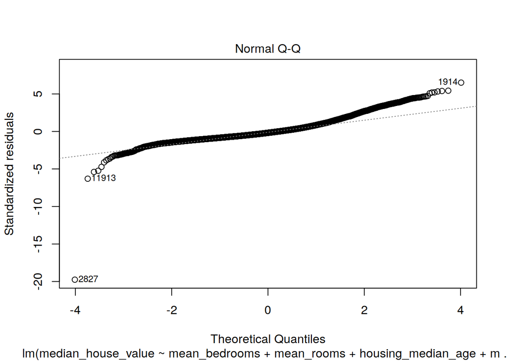

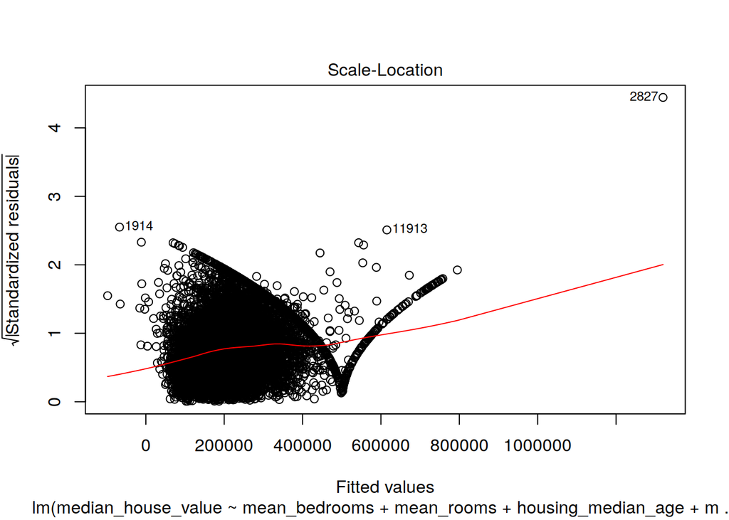

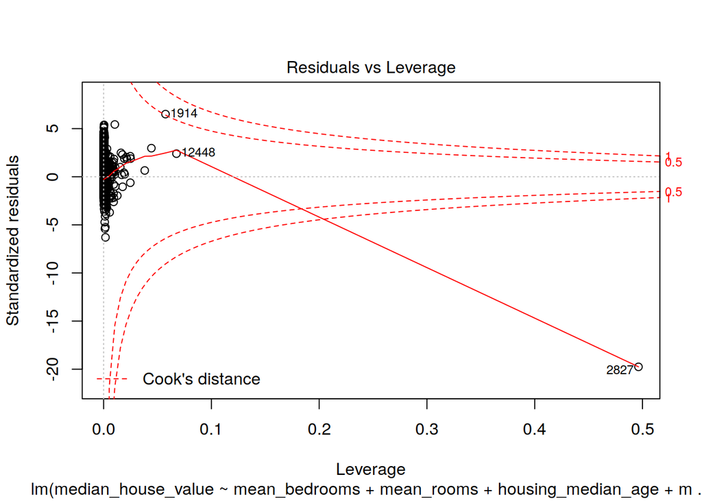

```r
plot(lineModel3)
```